# Machine Learning Course Final Project

Mónica Figueroa

November 2016

## Introduction.

This project used data from a study related to activity recognition (Velloso et al., 2013). The aim of the study was to predict categories of performance of a weight-lifting exercise (Unilateral Dumbbell Biceps Curl) using data generated by sensors placed in specific parts of the body of six male participants. The data of this study can be retrived in [Human Activity Recognition Webpage](http://groupware.les.inf.puc-rio.br/har#dataset). For this project two data sets were used:  
* A training data set (https://d396qusza40orc.cloudfront.net/predmachlearn/pml-training.csv)  
* A test data set (https://d396qusza40orc.cloudfront.net/predmachlearn/pml-testing.csv)

## Data pre-processing.

A first look into the training data lead to:

```r
DATOS<-read.csv("pml-training.csv", na.strings = c("#DIV/0!","NA", ""), stringsAsFactors = FALSE)
PROP_NA <- apply(DATOS, 2, function(x) sum(is.na(x)))/nrow(DATOS) # Proportion of NAs per variable
HIGH_PROP_NA<-PROP_NA > 0.3 # Identify those variables with high amount of NAs (more than 30%)
DATOS2<-DATOS[, !HIGH_PROP_NA] # Eliminate variables with a high proportion of NAs
DATOS2<-DATOS2[, -(1:7)]

# Same treatment to de test data
TEST<-read.csv("pml-testing.csv", na.strings = c("#DIV/0!","NA", ""), stringsAsFactors = FALSE)
PROP_NA_TEST <- apply(TEST, 2, function(x) sum(is.na(x)))/nrow(TEST)
HIGH_PROP_NA_TEST <- PROP_NA_TEST > 0.3
TEST<-TEST[, !HIGH_PROP_NA_TEST]
TEST<-TEST[, -(1:7)]

# Partition of the procesed training data set
library(caret)
set.seed(1234)
inTrain<-createDataPartition(DATOS2$classe, p = 0.75)[[1]]
training<-DATOS2[inTrain,]
testing<-DATOS2[-inTrain,]
```

## Fiting a model.

A random forest model was build with the training data set. I selected this model because despite the fact that fiftythree variables are too many variables none of them by themselves seem to have classificatory power (analysis not shown). Even using principal components the information is not capture in few components. The graph above shows how its no posible to classify correctly with the first two components which are the onse with more information in relation to the resto of the components.

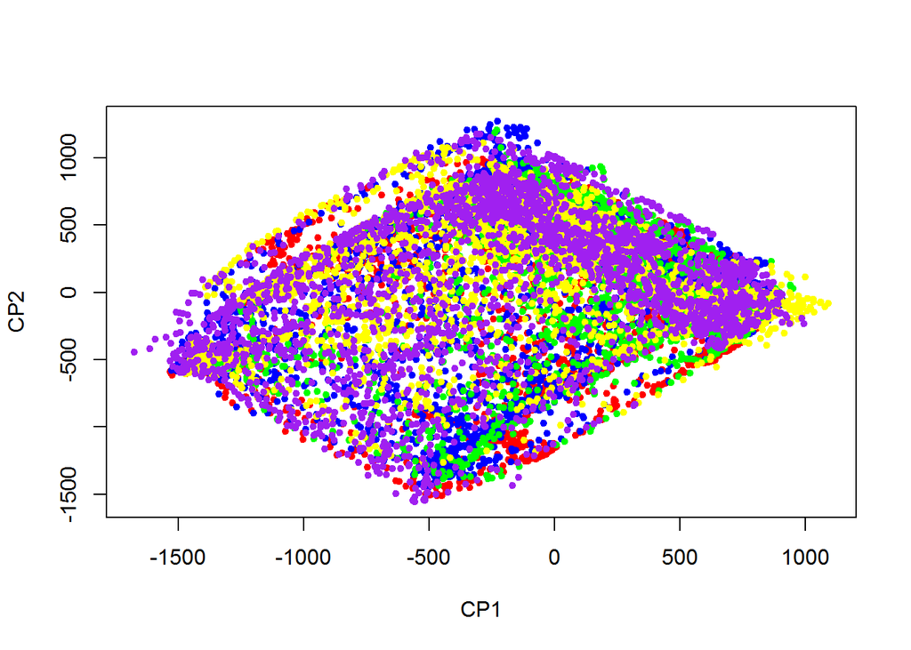

```r
compos<-princomp(training[,-53])
CP1<-compos$scores[,1]
CP2<-compos$scores[,2]
colores<-as.factor(training$classe)
plot(CP1, CP2, pch=20, col = c("red", "blue", "green", "yellow", "purple")[colores])
```

```r
set.seed(5678)
mod1<-train(classe ~ . , method = "rf", data = training, ntree = 10)
mod1
```

```
## Random Forest
##
## 14718 samples
##    52 predictor
##     5 classes: 'A', 'B', 'C', 'D', 'E'
##
## No pre-processing
## Resampling: Bootstrapped (25 reps)
## Summary of sample sizes: 14718, 14718, 14718, 14718, 14718, 14718, ...
## Resampling results across tuning parameters:
##
##   mtry  Accuracy   Kappa      Accuracy SD  Kappa SD
##    2    0.9727236  0.9654780  0.002604740  0.003304982
##   27    0.9820510  0.9772907  0.002278324  0.002884683
##   52    0.9732082  0.9660989  0.003857625  0.004906018
##
## Accuracy was used to select the optimal model using  the largest value.
## The final value used for the model was mtry = 27.
```

## Testing the model

Testing the model with the testing set (not the 20 testing set) gave a high accuracy.

```r
confusionMatrix(testing$classe, predict(mod1, testing))
```

```
## Confusion Matrix and Statistics
##
##           Reference
## Prediction    A    B    C    D    E
##          A 1395    0    0    0    0
##          B    7  933    8    0    1
##          C    0   11  838    6    0
##          D    0    1   11  791    1
##          E    0    2    2    2  895
##
## Overall Statistics
##
##                Accuracy : 0.9894
##                  95% CI : (0.9861, 0.9921)
##     No Information Rate : 0.2859
##     P-Value [Acc > NIR] : < 2.2e-16
##
##                   Kappa : 0.9866
##  Mcnemar's Test P-Value : NA
##
## Statistics by Class:
##
##                      Class: A Class: B Class: C Class: D Class: E
## Sensitivity            0.9950   0.9852   0.9756   0.9900   0.9978
## Specificity            1.0000   0.9960   0.9958   0.9968   0.9985
## Pos Pred Value         1.0000   0.9831   0.9801   0.9838   0.9933
## Neg Pred Value         0.9980   0.9965   0.9948   0.9980   0.9995
## Prevalence             0.2859   0.1931   0.1752   0.1629   0.1829
## Detection Rate         0.2845   0.1903   0.1709   0.1613   0.1825
## Detection Prevalence   0.2845   0.1935   0.1743   0.1639   0.1837
## Balanced Accuracy      0.9975   0.9906   0.9857   0.9934   0.9981
```

## Conclusion.

The random forest model was efficient in detecting the different kinds of performance categories. The sensor generated data, although is noisy, together work well to identify the most common mistakes made at the Unilateral Dumbbell Biceps Curl excersise.

## References

Velloso, E.; Bulling, A.; Gellersen, H.; Ugulino, W.; Fuks, H. Qualitative Activity Recognition of Weight Lifting Exercises. Proceedings of 4th International Conference in Cooperation with SIGCHI (Augmented Human ’13) . Stuttgart, Germany: ACM SIGCHI, 2013.